# Setup and Context

[figure not shown]

### Introduction

Dr Ignaz Semmelweis was a Hungarian physician born in 1818 who worked in the Vienna General Hospital. In the past people thought of illness as caused by "bad air" or evil spirits. But in the 1800s Doctors started looking more at anatomy, doing autopsies and started making arguments based on data. Dr Semmelweis suspected that something was going wrong with the procedures at Vienna General Hospital. Semmelweis wanted to figure out why so many women in maternity wards were dying from childbed fever (i.e., [puerperal fever](https://en.wikipedia.org/wiki/Postpartum_infections)).

[figure not shown]

Today you will become Dr Semmelweis. This is your office 👆. You will step into Dr Semmelweis' shoes and analyse the same data collected from 1841 to 1849.

### The Data Source

Dr Semmelweis published his research in 1861. I found the scanned pages of the [full text with the original tables in German](http://www.deutschestextarchiv.de/book/show/semmelweis_kindbettfieber_1861), but an excellent [English translation can be found here](http://graphics8.nytimes.com/images/blogs/freakonomics/pdf/the%20etiology,%20concept%20and%20prophylaxis%20of%20childbed%20fever.pdf).

[figure not shown]

### Upgrade plotly (only Google Colab Notebook)

Google Colab may not be running the latest version of plotly. If you're working in Google Colab, uncomment the line below, run the cell, and restart your notebook server.

```python
# %pip install --upgrade plotly
```

### Import Statements

```python
import pandas as pd
import numpy as np
from scipy import stats
import plotly.express as px
import seaborn as sns
import matplotlib.pyplot as plt
import matplotlib.dates as mdates
```

### Notebook Presentation

```python
pd.options.display.float_format = '{:,.2f}'.format

# Create locators for ticks on the time axis


from pandas.plotting import register_matplotlib_converters
register_matplotlib_converters()
```

### Read the Data

```python
df_yearly = pd.read_csv('annual_deaths_by_clinic.csv')
# parse_dates avoids DateTime conversion later
df_monthly = pd.read_csv('monthly_deaths.csv',
                      parse_dates=['date'])
years = mdates.YearLocator()
months = mdates.MonthLocator()
years_fmt = mdates.DateFormatter('%Y')
# Here, In order to parse dates as dates in the dataframe, we've used parse_dates argument.
```

# Preliminary Data Exploration

**Challenge**: Check out these two DataFrames ☝️.

- What is the shape of df_yearly and df_monthly? How many rows and columns?
- What are the column names?
- Which years are included in the dataset?
- Are there any NaN values or duplicates?
- What were the average number of births that took place per month?
- What were the average number of deaths that took place per month?

```python
print(f"The shape of df_yearly is {df_yearly.shape}")
print(f"The shape of df_monthly is {df_monthly.shape}")
```

```
The shape of df_yearly is (12, 4)
The shape of df_monthly is (98, 3)
```

```python
print(f"The columns in df_yearly are {df_yearly.columns}")
print(f"The columns in df_monthly are {df_monthly.columns}")
df_yearly.year
```

```
The columns in df_yearly are Index(['year', 'births', 'deaths', 'clinic'], dtype='object')
The columns in df_monthly are Index(['date', 'births', 'deaths'], dtype='object')
```

```
0     1841
1     1842
2     1843
3     1844
4     1845
5     1846
6     1841
7     1842
8     1843
9     1844
10    1845
11    1846
Name: year, dtype: int64
```

```python
df_yearly.isna().values.any()
```

```
False
```

```python
df_monthly.isna().values.any()
```

```
False
```

```python
df_yearly[df_yearly.duplicated()].values.any()
```

```
False
```

```python
df_monthly[df_monthly.duplicated()].values.any()
```

```
False
```

### Check for Nan Values and Duplicates

```python
print(f"The average number of births that took place per month is {df_monthly['births'].mean()}")
print(f"The average number of deaths that took place per month is {round(df_monthly['deaths'].mean(), 2)}")
```

```
The average number of births that took place per month is 267.0
The average number of deaths that took place per month is 22.47
```

### Descriptive Statistics

```python
df_yearly.describe()
```

|  | year | births | deaths |
| --- | --- | --- | --- |
| count | 12.00 | 12.00 | 12.00 |
| mean | 1,843.50 | 3,152.75 | 223.33 |
| std | 1.78 | 449.08 | 145.38 |
| min | 1,841.00 | 2,442.00 | 66.00 |
| 25% | 1,842.00 | 2,901.75 | 100.25 |
| 50% | 1,843.50 | 3,108.50 | 219.50 |
| 75% | 1,845.00 | 3,338.25 | 263.50 |
| max | 1,846.00 | 4,010.00 | 518.00 |

```python
df_monthly.describe()
```

|  | births | deaths |
| --- | --- | --- |
| count | 98.00 | 98.00 |
| mean | 267.00 | 22.47 |
| std | 41.77 | 18.14 |
| min | 190.00 | 0.00 |
| 25% | 242.50 | 8.00 |
| 50% | 264.00 | 16.50 |
| 75% | 292.75 | 36.75 |
| max | 406.00 | 75.00 |

### Percentage of Women Dying in Childbirth

**Challenge**: How dangerous was childbirth in the 1840s in Vienna?

- Using the annual data, calculate the percentage of women giving birth who died throughout the 1840s at the hospital.

In comparison, the United States recorded 18.5 maternal deaths per 100,000 or 0.018% in 2013 [(source).](https://en.wikipedia.org/wiki/Maternal_death#:~:text=The%20US%20has%20the%20%22highest,17.8%20per%20100%2C000%20in%202009)

```python
per_death_rate = (df_yearly["deaths"].sum() / df_yearly["births"].sum()) * 100
print(f"Maternal death rate in 1840s in Vienna during childbirth is {per_death_rate:.3}%")
```

```
Maternal death rate in 1840s in Vienna during childbirth is 7.08%
```

# Visualise the Total Number of Births 🤱 and Deaths 💀 over Time

### Plot the Monthly Data on Twin Axes

**Challenge**: Create a [Matplotlib chart](https://matplotlib.org/3.3.2/api/_as_gen/matplotlib.pyplot.plot.html) with twin y-axes. It should look something like this:

[figure not shown]

- Format the x-axis using locators for the years and months (Hint: we did this in the Google Trends notebook)
- Set the range on the x-axis so that the chart lines touch the y-axes
- Add gridlines
- Use `skyblue` and `crimson` for the line colours
- Use a dashed line style for the number of deaths
- Change the line thickness to 3 and 2 for the births and deaths respectively.
- Do you notice anything in the late 1840s?

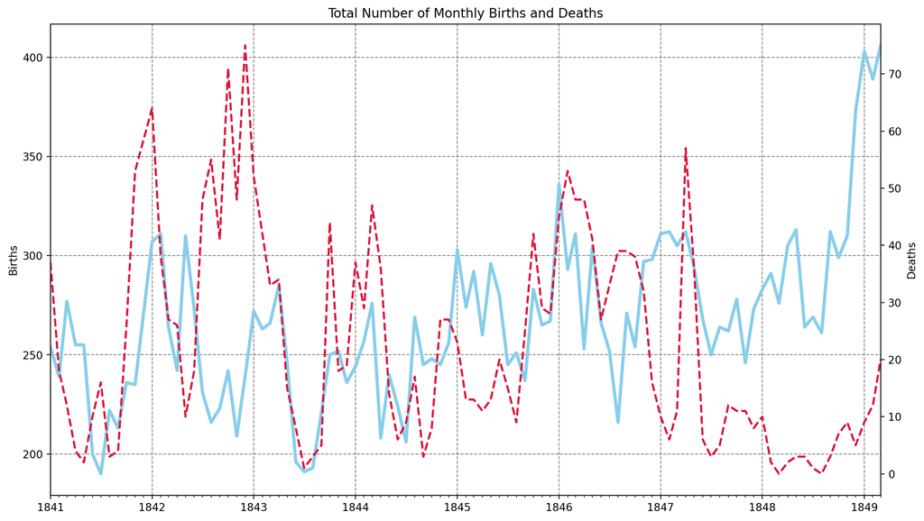

```python
plt.figure(figsize=(14, 8), dpi=200)
ax1 = plt.gca()
ax2 = ax1.twinx()

plt.title("Total Number of Monthly Births and Deaths")
ax1.grid(color='grey', linestyle='--')
ax1.plot(df_monthly["date"],
         df_monthly["births"],
         color='skyblue',
         linewidth=3)
ax2.plot(df_monthly["date"],
         df_monthly["deaths"],
         color='crimson',
         linewidth=2,
         linestyle='--')
ax1.xaxis.set_major_locator(years)
ax1.xaxis.set_minor_locator(months)
ax1.xaxis.set_major_formatter(years_fmt)

ax1.set_ylabel("Births")
ax2.set_ylabel("Deaths")
plt.xlim(df_monthly["date"].min(), df_monthly["date"].max())
plt.show()
```

# The Yearly Data Split by Clinic

Now let's look at the annual data instead.

**Challenge**: Use plotly to create line charts of the births and deaths of the two different clinics at the Vienna General Hospital.

- Which clinic is bigger or more busy judging by the number of births?
- Has the hospital had more patients over time?
- What was the highest number of deaths recorded in clinic 1 and clinic 2?

```python
# ax1 = plt.gca()
# ax2 = ax1.twinx()

# clinic1_data = df_yearly[df_yearly['clinic'] == 'clinic 1']
# clinic2_data = df_yearly[df_yearly['clinic'] == 'clinic 2']
# plt.title("Clinic 1 Data")

# ax1.grid(color='grey', linestyle='--')
# ax1.plot(clinic1_data["year"],
#          clinic1_data["births"],
#          color='skyblue',
#          linewidth=3)
# ax2.plot(clinic1_data["year"],
#          clinic1_data["deaths"],
#          color='crimson',
#          linewidth=2,
#          linestyle='--')

# ax1.set_ylabel("Births")
# ax2.set_ylabel("Deaths")

# plt.xlim(clinic1_data["year"].min(), clinic1_data["year"].max())
# plt.show()
line = px.line(df_yearly,
               x='year',
               y='births',
               color='clinic',
               title='Total Yearly Births by Clinic')
line.show()
```

[interactive chart not shown]

```python
# ax1 = plt.gca()
# ax2 = ax1.twinx()

# plt.title("Clinic 2 Data")

# ax1.grid(color='grey', linestyle='--')
# ax1.plot(clinic2_data["year"],
#          clinic2_data["births"],
#          color='skyblue',
#          linewidth=3)
# ax2.plot(clinic2_data["year"],
#          clinic2_data["deaths"],
#          color='crimson',
#          linewidth=2,
#          linestyle='--')

# ax1.set_ylabel("Births")
# ax2.set_ylabel("Deaths")

# plt.xlim(clinic2_data["year"].min(), clinic2_data["year"].max())
# plt.show()
line = px.line(df_yearly,
               x='year',
               y='deaths',
               color='clinic',
               title='Total Yearly Deaths by Clinic')
line.show()
```

[interactive chart not shown]

### Calculate the Proportion of Deaths at Each Clinic

**Challenge**: Calculate the proportion of maternal deaths per clinic. That way we can compare like with like.

- Work out the percentage of deaths for each row in the `df_yearly` DataFrame by adding a column called "pct_deaths".
- Calculate the average maternal death rate for clinic 1 and clinic 2 (i.e., the total number of deaths per the total number of births).
- Create another plotly line chart to see how the percentage varies year over year with the two different clinics.
- Which clinic has a higher proportion of deaths?
- What is the highest monthly death rate in clinic 1 compared to clinic 2?

```python
df_yearly["pct_deaths"] = (df_yearly['deaths'] / df_yearly["births"]) * 100
df_yearly
```

|  | year | births | deaths | clinic | pct_deaths |
| --- | --- | --- | --- | --- | --- |
| 0 | 1841 | 3036 | 237 | clinic 1 | 7.81 |
| 1 | 1842 | 3287 | 518 | clinic 1 | 15.76 |
| 2 | 1843 | 3060 | 274 | clinic 1 | 8.95 |
| 3 | 1844 | 3157 | 260 | clinic 1 | 8.24 |
| 4 | 1845 | 3492 | 241 | clinic 1 | 6.90 |
| 5 | 1846 | 4010 | 459 | clinic 1 | 11.45 |
| 6 | 1841 | 2442 | 86 | clinic 2 | 3.52 |
| 7 | 1842 | 2659 | 202 | clinic 2 | 7.60 |
| 8 | 1843 | 2739 | 164 | clinic 2 | 5.99 |
| 9 | 1844 | 2956 | 68 | clinic 2 | 2.30 |
| 10 | 1845 | 3241 | 66 | clinic 2 | 2.04 |
| 11 | 1846 | 3754 | 105 | clinic 2 | 2.80 |

### Plotting the Proportion of Yearly Deaths by Clinic

```python
line = px.line(df_yearly,
               x='year',
               y='pct_deaths',
               color='clinic',
               title='Proportion of Yearly Deaths by Clinic')

line.show()
```

[interactive chart not shown]

```python
# print(f"The average Maternal Death Rate in Clinic 1 is {df_yearly[df_yearly['clinic'] == 'clinic 1']['pct_deaths'].mean():.3}")
# print(f"The average Maternal Death Rate in Clinic 2 is {df_yearly[df_yearly['clinic'] == 'clinic 2']['pct_deaths'].mean():.3}")
clinic_1 = df_yearly[df_yearly.clinic == 'clinic 1']
avg_c1 = clinic_1.deaths.sum() / clinic_1.births.sum() * 100
print(f'Average death rate in clinic 2 is {avg_c1:.3}%.')
clinic_2 = df_yearly[df_yearly.clinic == 'clinic 2']
avg_c2 = clinic_2.deaths.sum() / clinic_2.births.sum() * 100
print(f'Average death rate in clinic 2 is {avg_c2:.3}%.')
```

[output not shown]

# The Effect of Handwashing

```python
# Date when handwashing was made mandatory
handwashing_start = pd.to_datetime('1847-06-01')
```

**Challenge**:

```python
df_monthly["pct_deaths"] = (df_monthly["deaths"] / df_monthly["births"])
```

```python
handwash_date = pd.to_datetime("1847-06-01")
before_handwash = df_monthly[df_monthly["date"] < handwash_date]
after_handwash = df_monthly[df_monthly["date"] >= handwash_date]
print(f"The Average death rate prior to June 1847 is {(before_handwash['pct_deaths'].mean())*100:.3}%.")
print(f"The Average death rate after June 1847 is {(after_handwash['pct_deaths'].mean())*100:.3}%.")
```

```
The Average death rate prior to June 1847 is 10.5%.
The Average death rate after June 1847 is 2.11%.
```

### Calculate a Rolling Average of the Death Rate

**Challenge**: Create a DataFrame that has the 6 month rolling average death rate prior to mandatory handwashing.

*Hint*: You'll need to set the dates as the index in order to avoid the date column being dropped during the calculation.

```python
rolling_death_rate_df_before = before_handwash[["date", "pct_deaths"]]
rolling_death_rate_df_before["pct_deaths"] = rolling_death_rate_df_before["pct_deaths"].rolling(window=6).mean()
rolling_death_rate_df_before.dropna()
```

|  | date | pct_deaths |
| --- | --- | --- |
| 5 | 1841-06-01 | 0.06 |
| 6 | 1841-07-01 | 0.05 |
| 7 | 1841-08-01 | 0.04 |
| 8 | 1841-09-01 | 0.03 |
| 9 | 1841-10-01 | 0.05 |
| ... | ... | ... |
| 71 | 1847-01-01 | 0.11 |
| 72 | 1847-02-01 | 0.08 |
| 73 | 1847-03-01 | 0.07 |
| 74 | 1847-04-01 | 0.07 |
| 75 | 1847-05-01 | 0.07 |

71 rows × 2 columns

### Highlighting Subsections of a Line Chart

**Challenge**: Copy-paste and then modify the Matplotlib chart from before to plot the monthly death rates (instead of the total number of births and deaths). The chart should look something like this:

[figure not shown]

- Add 3 seperate lines to the plot: the death rate before handwashing, after handwashing, and the 6-month moving average before handwashing.
- Show the monthly death rate before handwashing as a thin dashed black line.
- Show the moving average as a thicker, crimon line.
- Show the rate after handwashing as a skyblue line with round markers.
- Look at the [code snippet in the documentation to see how you can add a legend](https://matplotlib.org/3.1.1/api/_as_gen/matplotlib.pyplot.legend.html) to the chart.

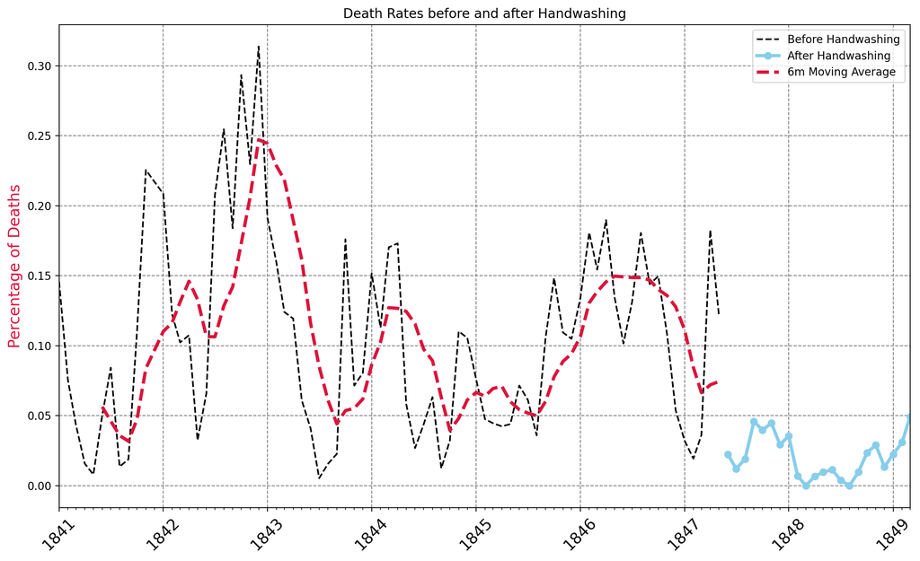

```python
plt.figure(figsize=(14, 8), dpi=200)

plt.grid(linestyle="--", color="grey")

plt.plot(before_handwash["date"],
         before_handwash["pct_deaths"],
         color='black',
         linestyle='--',
         label="Before Handwashing")

plt.plot(after_handwash["date"],
         after_handwash["pct_deaths"],
         color='skyblue',
         linewidth=3,
         marker="o",
         label="After Handwashing")

plt.plot(rolling_death_rate_df_before["date"],
         rolling_death_rate_df_before["pct_deaths"],
         color='crimson',
         linewidth=3,
         linestyle='--',
         label="6m Moving Average")

plt.title("Death Rates before and after Handwashing")

plt.legend()

plt.xticks(fontsize=14, rotation=45)
plt.xlim(df_monthly["date"].min(), df_monthly["date"].max())
plt.ylabel("Percentage of Deaths", color="crimson", fontsize=14)
plt.gca().xaxis.set_major_locator(years)
plt.gca().xaxis.set_minor_locator(months)

plt.show()
```

### Statistics - Calculate the Difference in the Average Monthly Death Rate

**Challenge**:

- What was the average percentage of monthly deaths before handwashing?
- What was the average percentage of monthly deaths after handwashing was made obligatory?
- By how much did handwashing reduce the average chance of dying in childbirth in percentage terms?
- How do these numbers compare to the average for all the 1840s that we calculated earlier?
- How many times lower are the chances of dying after handwashing compared to before?

```python
avg_mnth_death_before_handwash = (before_handwash["deaths"].sum()/before_handwash["births"].sum()) * 100
avg_mnth_death_after_handwash = (after_handwash["deaths"].sum()/after_handwash["births"].sum()) * 100
print(f"The average percentage of monthly deaths before handwashing was {avg_mnth_death_before_handwash:.3}%")
print(f"The average percentage of monthly deaths after handwashing was {avg_mnth_death_after_handwash:.3}%")
saved_lives = avg_mnth_death_before_handwash - avg_mnth_death_after_handwash
print(f"The handwashing reduce the average chance of dying in childbirth in percentage terms is {saved_lives:.3}%")
times = avg_mnth_death_before_handwash / avg_mnth_death_after_handwash
print(f"The chances of dying after handwashing compared to befores is lowered by {times:.3} times.")
# before_handwash.drop("monthly_average", axis=1)
```

```
The average percentage of monthly deaths before handwashing was 10.5%
The average percentage of monthly deaths after handwashing was 2.15%
The handwashing reduce the average chance of dying in childbirth in percentage terms is 8.37%
The chances of dying after handwashing compared to befores is lowered by 4.89 times.
```

### Use Box Plots to Show How the Death Rate Changed Before and After Handwashing

**Challenge**:

- Use [NumPy's `.where()` function](https://numpy.org/doc/stable/reference/generated/numpy.where.html) to add a column to `df_monthly` that shows if a particular date was before or after the start of handwashing.
- Then use plotly to create box plot of the data before and after handwashing.
- How did key statistics like the mean, max, min, 1st and 3rd quartile changed as a result of the new policy?

```python
df_monthly["handwashing_status"] = np.where(df_monthly["date"]< handwash_date, False, True)
df_monthly
# Here, I used numpy's where() in order to create an array of True and False values based on the condition.
```

|  | date | births | deaths | pct_deaths | handwashing_status |
| --- | --- | --- | --- | --- | --- |
| 0 | 1841-01-01 | 254 | 37 | 0.15 | False |
| 1 | 1841-02-01 | 239 | 18 | 0.08 | False |
| 2 | 1841-03-01 | 277 | 12 | 0.04 | False |
| 3 | 1841-04-01 | 255 | 4 | 0.02 | False |
| 4 | 1841-05-01 | 255 | 2 | 0.01 | False |
| ... | ... | ... | ... | ... | ... |
| 93 | 1848-11-01 | 310 | 9 | 0.03 | True |
| 94 | 1848-12-01 | 373 | 5 | 0.01 | True |
| 95 | 1849-01-01 | 403 | 9 | 0.02 | True |
| 96 | 1849-02-01 | 389 | 12 | 0.03 | True |
| 97 | 1849-03-01 | 406 | 20 | 0.05 | True |

98 rows × 5 columns

```python
px.box(df_monthly,
       x='handwashing_status',
       y='pct_deaths',
       color='handwashing_status',
       title='How the stats have changed after Handwashing')
```

[interactive chart not shown]

### Use Histograms to Visualise the Monthly Distribution of Outcomes

**Challenge**: Create a [plotly histogram](https://plotly.com/python/histograms/) to show the monthly percentage of deaths.

- Use docs to check out the available parameters. Use the [`color` parameter](https://plotly.github.io/plotly.py-docs/generated/plotly.express.histogram.html) to display two overlapping histograms.
- The time period of handwashing is shorter than not handwashing. Change `histnorm` to `percent` to make the time periods comparable.
- Make the histograms slighlty transparent
- Experiment with the number of bins on the histogram. Which number work well in communicating the range of outcomes?
- Just for fun, display your box plot on the top of the histogram using the `marginal` parameter.

```python
fig = px.histogram(df_monthly,
             x="pct_deaths",
             color='handwashing_status',
             histnorm='percent',
             barmode='overlay',
             opacity=0.6,
             nbins=30,
             marginal='box')

fig.update_layout(title="Percentage of Deaths monthly distribution",
                  yaxis_title="Count")

# Here, We are creating histogram to visualize the distribution of death percentage monthly before and after
# the handwashing.
# color argument is providing the color to the bars of the histogram based on the "handwashing_status" column.
# opacity argument is used to set the transparency of the histogram bars.
# nbins argument is used to set the number of bins on the histogram.
# barmode argument set to "overlay" is used to put the bars of histogram on top of each other.
# It makes easy to compare two datasets(before_handwash and after_handwash).
# histnorm argument set to "percent" is used to set the y-axis values as percentages rather than numbers.
# As, the records in dataset of after_handwash is lesser than the before_handwash.
# That's why if we consider only numbers then, the histogram becomes completely different.
# The count values of before_handwash will be more.
```

[interactive chart not shown]

### Use a Kernel Density Estimate (KDE) to visualise a smooth distribution

**Challenge**: Use [Seaborn's `.kdeplot()`](https://seaborn.pydata.org/generated/seaborn.kdeplot.html) to create two kernel density estimates of the `pct_deaths`, one for before handwashing and one for after.

- Use the `shade` parameter to give your two distributions different colours.
- What weakness in the chart do you see when you just use the default parameters?
- Use the `clip` parameter to address the problem.

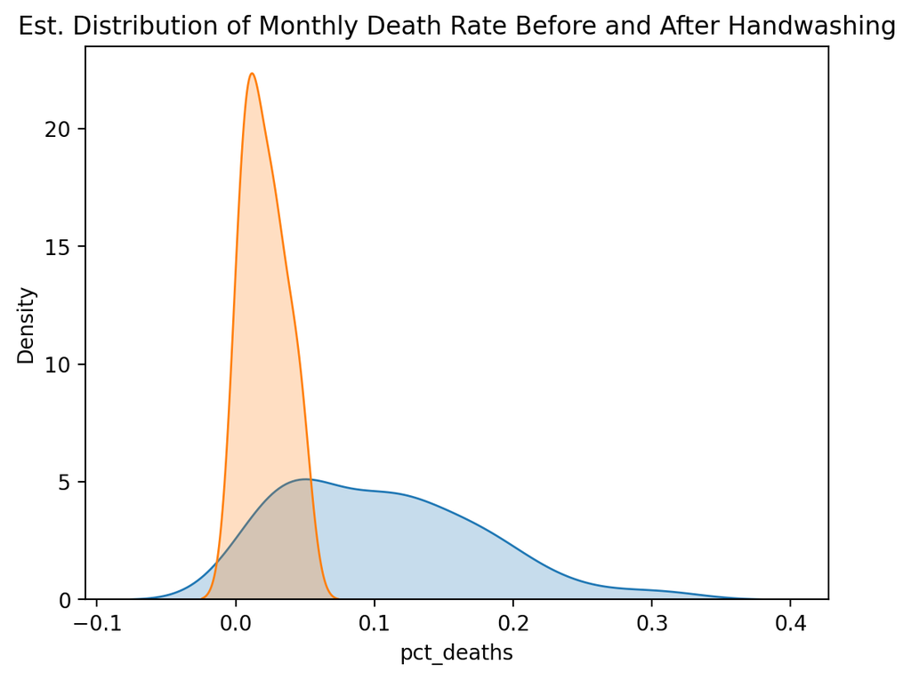

```python
# By default the distribution estimate includes a negative death rate!
plt.figure(dpi=200)
sns.kdeplot(before_handwash.pct_deaths, fill=True)
sns.kdeplot(after_handwash.pct_deaths, fill=True)
plt.title('Est. Distribution of Monthly Death Rate Before and After Handwashing')
plt.show()

# KDE is a method that is used to estimate and visualise the underlying probability distibution of a dateset.
# For example:- Imagine you have a set of data points, like ages of people in a group. KDE helps you answer
# questions like "What's the most likely age of a person in this group?" in a smooth and intuitive way.
# First, we smooth the data, to smooth it, we apply the kernel function at each data point.
# Then, KDE curve is constructed by summing all the individual kernel functions.
# THe shape of the curve represents the most likely value in the dataset. The peak of the curve
# represents the most likely value and valley(going downside) represents the less likely value.
# Kernel is a mathematical function
# In this code, we are creating KDE plot for before_handwash and after_handwash.
# In order to visualise the distribution of monthly death rate between both of the datasets.
# sns.kdeplot() is used to create kde plot.
# It takes the data that needs to be visualized.
# fill parameter refers to the area that is under kde curve, should be shaded.
```

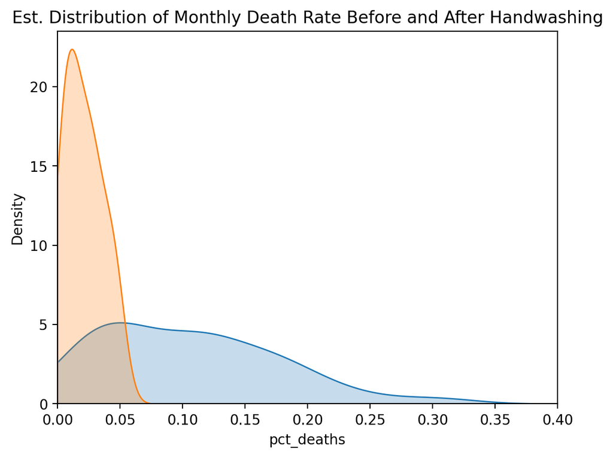

```python
# By default the distribution estimate includes a negative death rate!
plt.figure(dpi=200)
sns.kdeplot(before_handwash.pct_deaths, fill=True, clip=(0, 1))
sns.kdeplot(after_handwash.pct_deaths, fill=True, clip=(0, 1))
plt.title('Est. Distribution of Monthly Death Rate Before and After Handwashing')
plt.xlim(0, 0.40)
plt.show()

# Clip argument is used to limit the range of values when creating KDE plot.
```

### Use a T-Test to Show Statistical Significance

**Challenge**: Use a t-test to determine if the differences in the means are statistically significant or purely due to chance.

If the p-value is less than 1% then we can be 99% certain that handwashing has made a difference to the average monthly death rate.

- Import `stats` from scipy
- Use the [`.ttest_ind()` function](https://docs.scipy.org/]doc/scipy/reference/generated/scipy.stats.ttest_ind.html) to calculate the t-statistic and the p-value
- Is the difference in the average proportion of monthly deaths statistically significant at the 99% level?

```python
t_statistic, p_value = stats.ttest_ind(before_handwash["pct_deaths"], after_handwash["pct_deaths"])
print(f"The t_statistic is {t_statistic:.3}")
print(f"The p-value is {p_value:.10f}")

# As, we have done before, we find the difference between the mean/average of pct_deaths of both of the datasets(before and after handwash).
# Here, we are running a t-test to check whether the difference holds significance or just a purely due to chance.
# t-statistics is a numerical value that measures the difference between the mean of each group.
# If the t-statistics's value is higher then difference is strong and implies both of the means are apart of each other.
# p-value is a probability value that tells you the likelihood of obtaining the observed difference between the mean of both of the groups.
# If the p-value is lower then it rejects null-hypothesis(means no difference between the mean of both of the groups.)
# Here our p-value is less than 1% means that handwashing was definitely effective in preventing deaths.
```

```
The t_statistic is 5.51
The p-value is 0.0000002985
```